# Specialist Lesson 09 - Deep Neural Network Representation

```python
from google.colab import drive
drive.mount('/content/drive')
```

```python
path_Data = "/content/drive/MyDrive/AI Hoc Lieu /AI Specialist/Specialist Lesson 09 - Deep Neural Network Representation"
```

```python
defaultDir = %pwd
print("Current Directory of Folder : ", defaultDir)
WorkingDir = path_Data
%cd $WorkingDir
currentDir = %pwd
print("Current Directory of Folder : ", currentDir)
```

```
Current Directory of Folder :  /content
/content/drive/MyDrive/AI Hoc Lieu /AI Specialist/Specialist Lesson 09 - Deep Neural Network Representation
Current Directory of Folder :  /content/drive/MyDrive/AI Hoc Lieu /AI Specialist/Specialist Lesson 09 - Deep Neural Network Representation
```

# **Image Classification**

Một ví dụ phân loại ảnh trên tập dữ liệu FASHION MNIST.

## Giới thiệu FASHION MNIST

[Fashion MNIST](https://github.com/zalandoresearch/fashion-mnist) là bộ dữ liệu gồm 70000 ảnh xám kích thước $28 \times 28$ chia thành 10 class.

[figure not shown]

## **Import các thư viện cần dùng**

```python
try:
    %tensorflow_version 2.x
except Exception:
    pass
```

```python
import tensorflow as tf
from tensorflow import keras
import numpy as np
import matplotlib.pyplot as plt

print(tf.__version__)
```

```
2.5.0
```

## **Load và Explore data**

```python
fashion_mnist = keras.datasets.fashion_mnist
(x_train, y_train), (x_test, y_test) = fashion_mnist.load_data()
```

```
Downloading data from https://storage.googleapis.com/tensorflow/tf-keras-datasets/train-labels-idx1-ubyte.gz
Downloading data from https://storage.googleapis.com/tensorflow/tf-keras-datasets/train-images-idx3-ubyte.gz
Downloading data from https://storage.googleapis.com/tensorflow/tf-keras-datasets/t10k-labels-idx1-ubyte.gz
Downloading data from https://storage.googleapis.com/tensorflow/tf-keras-datasets/t10k-images-idx3-ubyte.gz
```

```python
print('training samples: ', len(x_train))
print('test samples: ', len(x_test))
print('classes: ', (y_train.max() + 1) )
print('image shape: ', x_train[0,...].shape)
print('max value: ', x_train.max())
print('min_value: ', x_train.min())
```

```
training samples:  60000
test samples:  10000
classes:  10
image shape:  (28, 28)
max value:  255
min_value:  0
```

Bảng label và class tương ứng:

| Label | Class |
| --- | --- |
| 0 | T-shirt/top |
| 1 | Trouser |
| 2 | Pullover |
| 3 | Dress |
| 4 | Coat |
| 5 | Sandal |
| 6 | Shirt |
| 7 | Sneaker |
| 8 | Bag |
| 9 | Ankle boot |

```python
class_names = ['T-shirt/top', 'Trouser', 'Pullover', 'Dress', 'Coat',
               'Sandal', 'Shirt', 'Sneaker', 'Bag', 'Ankle boot']
```

Chuẩn hóa data về $[0, 1]$:

```python
x_train = x_train / 255.0
x_test = x_test / 255.0
```

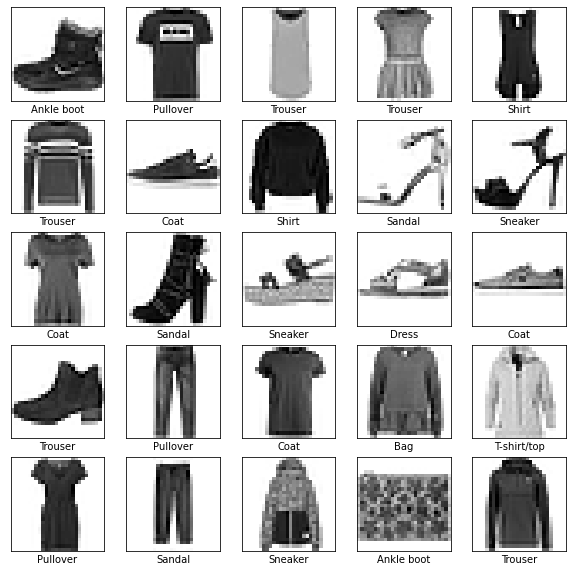

```python
plt.figure(figsize=(10, 10))
for i in range(25):
    plt.subplot(5, 5, i+1)
    plt.xticks([])
    plt.yticks([])
    plt.imshow(x_train[i], cmap='binary')
    plt.xlabel(class_names[y_test[i]])
plt.show()
```

## **Tạo model**

Một ví dụ về Neural Network (NN):

- Input layer: 3 unit
- Hidden layer: 4 unit
- Output layer: 2 unit (ứng với 2 class)

[figure not shown]

Chúng ta sẽ build một model NN tương tự như trên nhưng với các thông số như sau:

- Input layer: 28*28 = 784 unit
- Hidden layer: 128 unit
- Output layer: 10 unit (ứng với 10 class)

```python
model = keras.Sequential([
                          keras.layers.Flatten(input_shape=(28, 28)),
                          keras.layers.Dense(128, activation='relu'),
                          keras.layers.Dense(10)])
```

```python
model.summary()
```

```
Model: "sequential"
_________________________________________________________________
Layer (type)                 Output Shape              Param #
=================================================================
flatten (Flatten)            (None, 784)               0
_________________________________________________________________
dense (Dense)                (None, 128)               100480
_________________________________________________________________
dense_1 (Dense)              (None, 10)                1290
=================================================================
Total params: 101,770
Trainable params: 101,770
Non-trainable params: 0
_________________________________________________________________
```

```python
model.compile(optimizer='adam',
              loss=keras.losses.SparseCategoricalCrossentropy(from_logits=True),
              metrics=['accuracy'])
```

## **Training**

Thực hiện training 10 epoch.

*Note: 1 epoch tương ứng với 1 lần model được train trên toàn bộ training data*

```python
model.fit(x_train, y_train, epochs=10)
```

```
<tensorflow.python.keras.callbacks.History at 0x7f5b9034ac90>
```

## **Testing**

```python
test_loss, test_acc = model.evaluate(x_test, y_test)
```

[output not shown]

*Note: Overfiting là hiện tượng model tốt trên tập dữ liệu train nhưng kém trên tập dữ liệu test. Tạm gọi là giỏi học thuộc lòng, học vẹt, gặp cái mới là đứt.*

## **Kiểm tra và Hiển thị**

```python
prob_model = keras.Sequential([model, keras.layers.Softmax()])
```

```python
predictions = prob_model.predict(x_test)
```

```python
def plot_image(image, pred_probs, true_label):
    pred_label = pred_probs.argmax()
    pred_prob = pred_probs[pred_label] * 100.0
    plt.grid(False)
    plt.xticks([])
    plt.yticks([])
    plt.imshow(image, cmap='binary')
    if pred_label == true_label:
        color = 'blue'
    else:
        color = 'red'
    plt.xlabel("{} {:2.0f}% ({})".format(
                                        class_names[pred_label],
                                        pred_prob,
                                        class_names[true_label]
                                        ),
                                        color=color
                                    )
```

```python
def plot_value_array(image, pred_probs, true_label):
    pred_label = pred_probs.argmax()
    plt.grid(False)
    plt.xticks(range(10))
    plt.yticks([])
    thisplot = plt.bar(range(10), pred_probs, color="#777777")
    thisplot[pred_label].set_color('red')
    thisplot[true_label].set_color('blue')
    plt.ylim([0, 1])
```

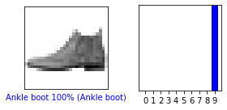

```python
plt.figure(figsize=(4, 2))
plt.subplot(1, 2, 1)
plot_image(x_test[0], predictions[0], y_test[0])
plt.subplot(1, 2, 2)
plot_value_array(x_test[0], predictions[0], y_test[0])
plt.tight_layout()
plt.show()
```

[figure not shown]

```python
n_rows = 5
n_cols = 3
n_images = n_rows * n_cols
plt.figure(figsize=(2*2*n_cols, 2*n_rows))
for i in range(n_images):
    plt.subplot(n_rows, 2*n_cols, 2*i + 1)
    plot_image(x_test[i], predictions[i], y_test[i])
    plt.subplot(n_rows, 2*n_cols, 2*i + 2)
    plot_value_array(x_test[i], predictions[i], y_test[i])
plt.tight_layout()
plt.show()
```

**Phân loại một bức ảnh**

```python
# ví dụ phân loại ảnh đầu tiên trong test set
img = x_test[0]
```

```python
print(img.shape)
```

```
(28, 28)
```

```python
# prob_model(img)
```

Lưu ý: đầu vào của hàm `model.predict` luôn phải là 1 batch. Trong trường hợp này đầu phải có shape là $(1, 28, 28)$

```python
img = img[np.newaxis,...]
print(img.shape)
```

```
(1, 28, 28)
```

```python
probs = prob_model(img).numpy()[0]
print(probs)
```

```
[2.5600215e-07 1.4379492e-11 2.8721713e-08 1.3568812e-11 7.2309319e-08
 6.1103009e-04 2.3478268e-08 1.9776709e-03 7.4791600e-08 9.9741083e-01]
```

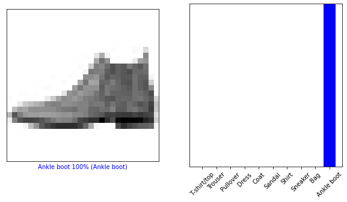

```python
plt.figure(figsize=(10, 5))
plt.subplot(1, 2, 1)
plot_image(img[0], probs, y_test[0])
plt.subplot(1, 2, 2)
plot_value_array(img[0], probs, y_test[0])
plt.xticks(range(10), class_names, rotation=45)
plt.show()
```

```python
# Import the necessary libraries
import numpy as np
import cv2
import matplotlib.pyplot as plt
from skimage import color
%matplotlib inline
```

```python
def ShowImage(ImageList, nRows = 1, nCols = 2, WidthSpace = 0.00, HeightSpace = 0.00):
    from matplotlib import pyplot as plt
    import matplotlib.gridspec as gridspec

    gs = gridspec.GridSpec(nRows, nCols)
    gs.update(wspace=WidthSpace, hspace=HeightSpace) # set the spacing between axes.
    plt.figure(figsize=(20,20))
    for i in range(len(ImageList)):
        ax1 = plt.subplot(gs[i])
        ax1.set_xticklabels([])
        ax1.set_yticklabels([])
        ax1.set_aspect('equal')

        plt.subplot(nRows, nCols,i+1)

        image = ImageList[i].copy()
        if (len(image.shape) < 3):
            plt.imshow(image, plt.cm.gray)
        else:
            plt.imshow(image)
        plt.title("Image " + str(i))
        plt.axis('off')

    plt.show()
```

```python
import os
import pandas as pd

def get_subfiles(dir):
    "Get a list of immediate subfiles"
    return next(os.walk(dir))[2]
```

```python
all_names = get_subfiles(path_Data)
ImageDB = []
NameDB = []
for i in range(len(all_names)):
    if('Fashion' in all_names[i]):
        tmp = cv2.imread(all_names[i])
        ImageDB.append(tmp)
        NameDB.append(all_names[i])

print("Number of Images:", len(NameDB))
```

```
Number of Images: 3
```

```
Selected Image :
Index  0
Name  Fashion_Test01.jpg
```

[figure not shown]

```python
FileName = 'Fashion_Test01.jpg'
idx = NameDB.index(FileName)
print("Selected Image : ", "\nIndex ", idx, "\nName ", NameDB[idx])

image_orig = ImageDB[idx]
img = cv2.cvtColor(image_orig,cv2.COLOR_BGR2RGB)
image_gray = cv2.cvtColor(image_orig,cv2.COLOR_BGR2GRAY)
image_hsv = cv2.cvtColor(image_orig, cv2.COLOR_BGR2HSV)
image_ycbcr = cv2.cvtColor(image_orig, cv2.COLOR_BGR2YCR_CB)
ShowImage([image_orig, img, image_gray, image_hsv, image_ycbcr], 1, 5)

img1 = image_gray.copy()          # queryImage
```

```python
the_img = cv2.imread(FileName,cv2.IMREAD_GRAYSCALE)
the_img = cv2.resize(the_img,(28,28))
```

```python
pixels = the_img.copy()
pixels = pixels.astype('float32')
# calculate global mean
mean = pixels.mean()
pixels = pixels - mean
the_img_convert = pixels.copy()
```

```
(28, 28) -205.86607 38.133926
```

[figure not shown]

```python
print(the_img_convert.shape, the_img_convert.min(), the_img_convert.max())
ShowImage([img, the_img, the_img_convert], 1, 5)
```

```python
# Add the image to a batch where it's the only member.
img_predict = (np.expand_dims(the_img_convert,0))
print(img_predict.shape)
```

```
(1, 28, 28)
```

```python
predictions_single = prob_model.predict(img_predict)
print(predictions_single)
print(np.argmax(predictions_single[0]))
```

```
[[0. 0. 0. 0. 0. 1. 0. 0. 0. 0.]]
5
```

```python
def plot_value_array(i, predictions_array, true_label):
  true_label = true_label[i]
  plt.grid(False)
  plt.xticks(range(10))
  plt.yticks([])
  thisplot = plt.bar(range(10), predictions_array, color="#777777")
  plt.ylim([0, 1])
  predicted_label = np.argmax(predictions_array)

  thisplot[predicted_label].set_color('red')
  thisplot[true_label].set_color('blue')
```

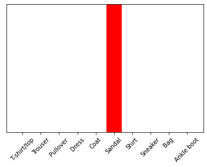

```python
plot_value_array(1, predictions_single[0], y_test)
_ = plt.xticks(range(10), class_names, rotation=45)
```

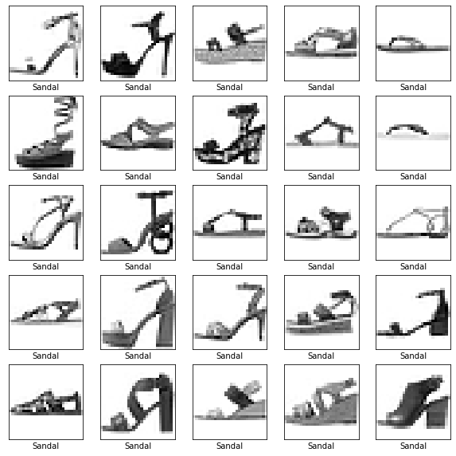

```python
plt.figure(figsize=(10,10))
count = 0
for i in range(x_train.shape[0]):
    if(class_names[y_train[i]] == "Sandal"):
        count = count + 1
        plt.subplot(5,5,count)
        plt.xticks([])
        plt.yticks([])
        plt.grid(False)
        plt.imshow(x_train[i], cmap=plt.cm.binary)
        plt.xlabel(class_names[y_train[i]])
    if(count == 25):
        break
plt.show()
```

```
Selected Image :
Index  2
Name  Fashion_Test02.jpg
```

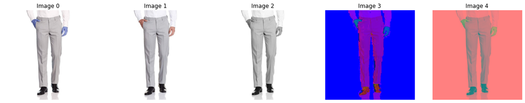

```python
FileName = 'Fashion_Test02.jpg'
idx = NameDB.index(FileName)
print("Selected Image : ", "\nIndex ", idx, "\nName ", NameDB[idx])

image_orig = ImageDB[idx]
img = cv2.cvtColor(image_orig,cv2.COLOR_BGR2RGB)
image_gray = cv2.cvtColor(image_orig,cv2.COLOR_BGR2GRAY)
image_hsv = cv2.cvtColor(image_orig, cv2.COLOR_BGR2HSV)
image_ycbcr = cv2.cvtColor(image_orig, cv2.COLOR_BGR2YCR_CB)
ShowImage([image_orig, img, image_gray, image_hsv, image_ycbcr], 1, 5)

img1 = image_gray.copy()          # queryImage
```

```
(28, 28) -19.141586 216.85841
```

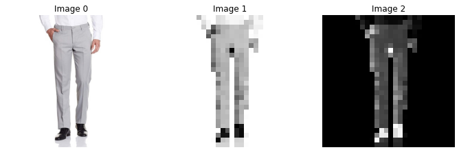

```python
# Local Centering
the_img = cv2.imread(FileName,cv2.IMREAD_GRAYSCALE)
the_img = cv2.resize(the_img,(28,28))

pixels = the_img.copy()
pixels = pixels.astype('float32')
# calculate global mean
mean = pixels.mean()
pixels = pixels - mean
the_img_convert = 1 - pixels.copy()
print(the_img_convert.shape, the_img_convert.min(), the_img_convert.max())
ShowImage([img, the_img, the_img_convert], 1, 5)
```

```
(1, 28, 28)
[[0. 1. 0. 0. 0. 0. 0. 0. 0. 0.]]
1
```

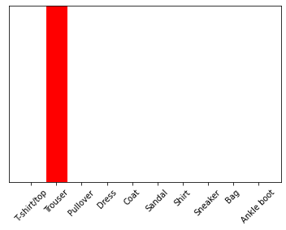

```python
# Add the image to a batch where it's the only member.
img_predict = (np.expand_dims(the_img_convert,0))
print(img_predict.shape)
predictions_single = prob_model.predict(img_predict)
print(predictions_single)
print(np.argmax(predictions_single[0]))
plot_value_array(1, predictions_single[0], y_test)
_ = plt.xticks(range(10), class_names, rotation=45)
```

```
Selected Image :
Index  1
Name  Fashion_Test03.jpg
```

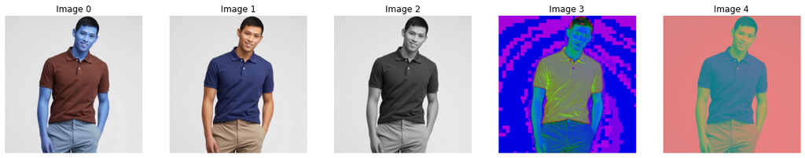

```python
FileName = 'Fashion_Test03.jpg'
idx = NameDB.index(FileName)
print("Selected Image : ", "\nIndex ", idx, "\nName ", NameDB[idx])

image_orig = ImageDB[idx]
img = cv2.cvtColor(image_orig,cv2.COLOR_BGR2RGB)
image_gray = cv2.cvtColor(image_orig,cv2.COLOR_BGR2GRAY)
image_hsv = cv2.cvtColor(image_orig, cv2.COLOR_BGR2HSV)
image_ycbcr = cv2.cvtColor(image_orig, cv2.COLOR_BGR2YCR_CB)
ShowImage([image_orig, img, image_gray, image_hsv, image_ycbcr], 1, 5)

img1 = image_gray.copy()          # queryImage
```

```
Mean: 176.349, Standard Deviation: 72.130
(28, 28) 0.089824855 3.2369404
```

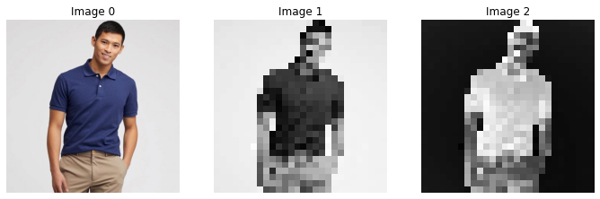

```
(1, 28, 28)
[[7.7097458e-01 6.2657997e-04 2.8604569e-03 2.0119956e-05 8.5629319e-05
  8.2291817e-15 1.9827332e-01 4.6818613e-21 2.7159225e-02 1.9992613e-10]]
0
```

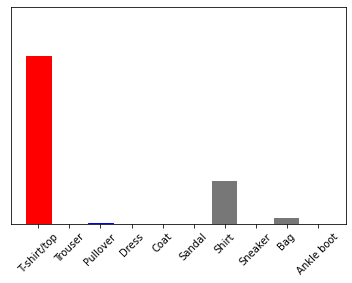

```python
from numpy import asarray
the_img = cv2.imread(FileName,cv2.IMREAD_GRAYSCALE)
the_img = cv2.resize(the_img,(28,28))

pixels = asarray(the_img)
# convert from integers to floats
pixels = pixels.astype('float32')
# calculate global mean and standard deviation
mean, std = pixels.mean(), pixels.std()
print('Mean: %.3f, Standard Deviation: %.3f' % (mean, std))
# global standardization of pixels
pixels = (pixels - mean) / std
the_img_convert = 1 - pixels.copy()

print(the_img_convert.shape, the_img_convert.min(), the_img_convert.max())
ShowImage([img, the_img, the_img_convert], 1, 5)

# Add the image to a batch where it's the only member.
img_predict = (np.expand_dims(the_img_convert,0))
print(img_predict.shape)
predictions_single = prob_model.predict(img_predict)
print(predictions_single)
print(np.argmax(predictions_single[0]))
plot_value_array(1, predictions_single[0], y_test)
_ = plt.xticks(range(10), class_names, rotation=45)
```